# Predictive Analysis

2022-12-07

Have a look at distributions of each variable to see if there is anything off from the distribution. Since missing values were imputed, there shouldn’t really be anything crazy going on.The spikes in each distribution is probably where the imputation resides.

```r
surgery_df_m <- surgery_df_x %>%
  subset(select = c(5:30))

melt.surgery <- reshape2::melt(surgery_df_m)
```

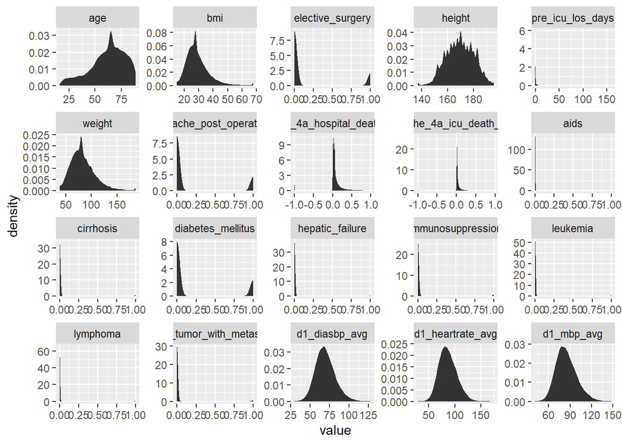

```r
ggplot(data = melt.surgery, aes(x = value)) +
stat_density() +
facet_wrap(~variable, scales = "free")
```

```r
#Lots of older patients requiring surgery. Most surgeries were not elective, hence were an emergency or life threatening.
```

```r
names(surgery_df_x) = gsub(pattern = "_avg*", replacement = "", x = names(surgery_df_x))#just making names a bit neater

surgery_df_x <- surgery_df_x%>%
  subset(select = -c(X,patient_id,
                     hospital_id,
                     apache_post_operative,
                     apache_2_bodysystem,
                     apache_3j_bodysystem,
                     apache_4a_icu_death_prob,
                     apache_4a_hospital_death_prob))       # A bit more tidying


split_sample <- sample.split(surgery_df_x, SplitRatio = 0.7)

train_set  <- subset(surgery_df_x, split_sample == TRUE)
test_set   <- subset(surgery_df_x, split_sample == FALSE)
```

Logistic Regression

```r
logistic_r <- glm(hospital_death ~ ., data = surgery_df_x, family = "binomial")
summary(logistic_r)
```

```
##
## Call:
## glm(formula = hospital_death ~ ., family = "binomial", data = surgery_df_x)
##
## Deviance Residuals:
##     Min       1Q   Median       3Q      Max
## -3.5200  -0.3809  -0.2614  -0.1791   3.3438
##
## Coefficients: (1 not defined because of singularities)
##                                             Estimate Std. Error z value
## (Intercept)                                2.534e+01  2.768e+00   9.154
## age                                        2.733e-02  1.053e-03  25.962
## bmi                                        3.076e-03  6.881e-03   0.447
## elective_surgery                          -8.262e-01  8.240e-02 -10.028
## ethnicityAfrican American                 -8.198e-02  1.255e-01  -0.653
## ethnicityAsian                            -9.802e-02  1.724e-01  -0.568
## ethnicityCaucasian                        -2.698e-02  1.171e-01  -0.230
## ethnicityHispanic                          1.851e-01  1.321e-01   1.402
## ethnicityNative American                   9.387e-02  1.900e-01   0.494
## ethnicityOther/Unknown                    -9.627e-03  1.329e-01  -0.072
## genderF                                   -1.027e+00  5.689e-01  -1.805
## genderM                                   -1.002e+00  5.687e-01  -1.762
## height                                     2.870e-03  3.078e-03   0.932
## icu_admit_sourceAccident & Emergency      -3.063e-01  3.688e-01  -0.831
## icu_admit_sourceFloor                     -1.317e-01  3.696e-01  -0.356
## icu_admit_sourceOperating Room / Recovery -5.705e-01  3.752e-01  -1.521
## icu_admit_sourceOther Hospital             2.510e-01  3.749e-01   0.670
## icu_admit_sourceOther ICU                 -4.796e-02  3.940e-01  -0.122
## icu_typeCCU-CTICU                         -2.415e-01  7.454e-02  -3.240
## icu_typeCSICU                             -4.535e-01  9.381e-02  -4.834
## icu_typeCTICU                             -2.798e-01  9.521e-02  -2.939
## icu_typeMed-Surg ICU                      -2.409e-01  5.796e-02  -4.156
## icu_typeMICU                              -1.413e-01  6.870e-02  -2.056
## icu_typeNeuro ICU                          4.107e-01  7.217e-02   5.691
## icu_typeSICU                              -8.021e-02  8.148e-02  -0.984
## pre_icu_los_days                           4.183e-02  4.404e-03   9.498
## weight                                    -3.250e-03  2.479e-03  -1.311
## aids                                       7.235e-01  3.741e-01   1.934
## cirrhosis                                  2.391e-01  1.101e-01   2.172
## diabetes_mellitus                         -2.885e-01  3.624e-02  -7.961
```

[output cut: 136 more lines]

```
## d1_pao2fio2ratio                           < 2e-16 ***
## h1_arterial_pco2                          0.224295
## h1_arterial_ph                            0.034237 *
## h1_arterial_po2                           0.270921
## h1_pao2fio2ratio                          0.119339
## ---
## Signif. codes:  0 '***' 0.001 '**' 0.01 '*' 0.05 '.' 0.1 ' ' 1
##
## (Dispersion parameter for binomial family taken to be 1)
##
##     Null deviance: 53378  on 90997  degrees of freedom
## Residual deviance: 40305  on 90914  degrees of freedom
## AIC: 40473
##
## Number of Fisher Scoring iterations: 6
```

```r
#Check the most important variables to model. Perhaps do a logistic regression
importances <- varImp(logistic_r)

importances %>%
  arrange(desc(Overall)) %>%
  top_n(20)
```

```
##                               Overall
## age                         25.961720
## d1_lactate                  25.500503
## d1_spo2                     24.387383
## d1_arterial_po2             17.549096
## d1_pao2fio2ratio            15.486882
## d1_wbc                      12.434954
## h1_temp                     10.849283
## d1_temp                     10.777765
## d1_bun                      10.096021
## elective_surgery            10.027621
## d1_heartrate                 9.743754
## pre_icu_los_days             9.498160
## d1_glucose                   9.066843
## solid_tumor_with_metastasis  9.010346
## h1_resprate                  8.498928
## d1_hco3                      8.370850
## diabetes_mellitus            7.960840
## d1_bilirubin                 7.905054
## d1_hemaglobin                7.026982
## d1_sysbp                     6.907716
```

```r
surgery_prob <- predict(logistic_r, newdata = test_set, type = "response")
```

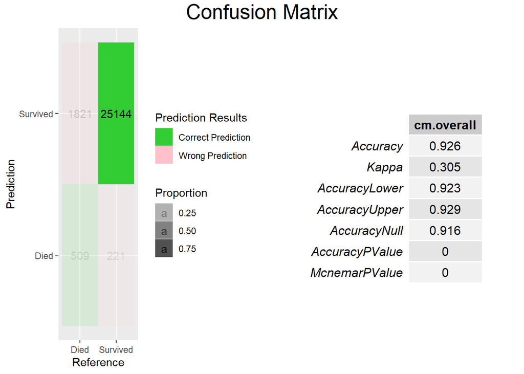

```r
pred <- ifelse(surgery_prob > 0.5, 1, 0)

cm <- confusionMatrix(factor(pred), factor(test_set$hospital_death), positive = as.character(1)) #Created Confusion Matrix
cm_d <- as.data.frame(cm$table)                                                                  #Bunch of Cleaning to prepare for a heatmap...ish
cm_st <-data.frame(cm$overall)                                                                   # confusion matrix statistics as data.frame
cm_st$cm.overall <- round(cm_st$cm.overall,3)                                                    #Lets do 3 sig figs
cm_d$diag <- cm_d$Prediction == cm_d$Reference                                                   # Get the Diagonal. True Predictions
cm_d$ndiag <- cm_d$Prediction != cm_d$Reference                                                  # Off Diagonal. Wrong Predictions
cm_d$Reference <-  likert::reverse.levels(cm_d$Reference)                                        # diagonal starts at top left
cm_d$ref_freq <- cm_d$Freq * ifelse(is.na(cm_d$diag),-1,1)

cm_d$Reference <- as.character(cm_d$Reference)
cm_d$Prediction <- as.character(cm_d$Prediction)

cm_d <- cm_d %>%
  mutate(Prediction = recode(Prediction, '1' = 'Died', '0' = 'Survived')) %>%
  mutate(Reference = recode(Reference, '1' = 'Died', '0' = 'Survived')) %>%
  mutate(diag = as.character(diag)) %>%
  mutate(diag = recode(diag, 'TRUE' = 'Correct Prediction', 'FALSE' = 'Wrong Prediction'))%>%
  mutate(Proportion = Freq/sum(Freq))

plt1 <-  ggplot(data = cm_d, aes(x = Reference , y = Prediction, fill = factor(diag), alpha = Proportion)) +
  geom_tile() +
  geom_text(aes(label=Freq),vjust = .5)+
  scale_fill_manual(values=c("limegreen", "pink")) +
  labs(fill = "Prediction Results")

plt2 <-  tableGrob(cm_st)

grid.arrange(plt1, plt2, nrow = 1, ncol = 2,
             top=textGrob("Confusion Matrix",gp=gpar(fontsize=20,font=1)))
```

When applying the logistic regression model to the test data, we get an accuracy of 92% with a p-value of <0.0001. This suggests that the model is statistically significant in explaining the survival rate. However, the Kappa value is quite meh at 0.3, suggesting fair agreement of the data. The next steps is to see if the model can be improved, either by increasing accuracy, or removing some redundant variables to minimize the amount of data that would be required.